# Using Gapminder

#4.2 Gapminder ##Faceting

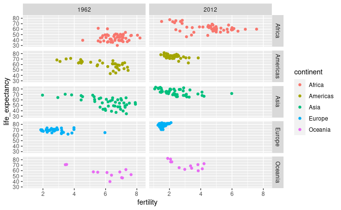

```r
library(dslabs)
library(dplyr)
library(tidyverse)
data(gapminder)
filter(gapminder, year %in% c(1962 , 2012)) %>%
  ggplot(aes(x = fertility, y= life_expectancy, col = continent))+
  geom_point() +
  facet_grid(continent~year)
```

```r
NA
NA
```

This shows the gapminder data using the grid facet.

Now we will look at the same data using only the continent or year

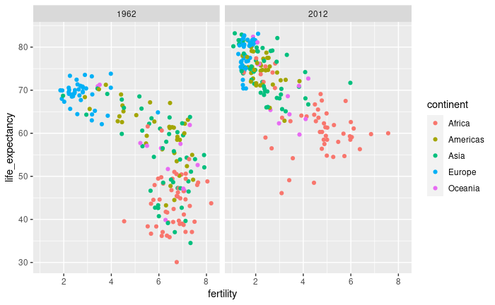

```r
library(dslabs)
library(tidyverse)
data("gapminder")
filter(gapminder , year %in% c(1962, 2012)) %>%
  ggplot(aes(x = fertility, y = life_expectancy , col = continent)) +
  geom_point () +
  facet_grid(.~year)
```

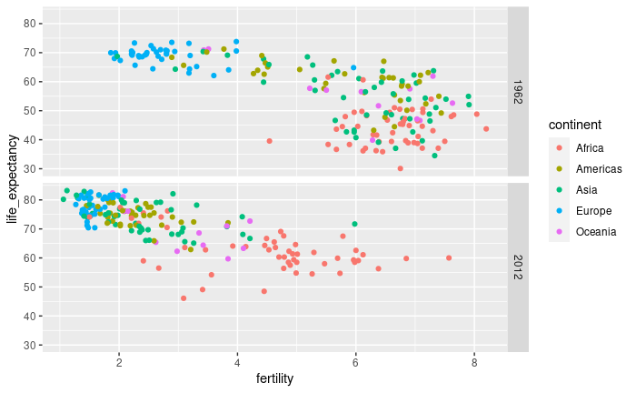

```r
filter(gapminder , year %in% c(1962 , 2012)) %>%
  ggplot(aes(x = fertility , y = life_expectancy, col = continent)) +
  geom_point() +
  facet_grid(year~.)
```

FAcet by year withy multiple rows to show the change over time

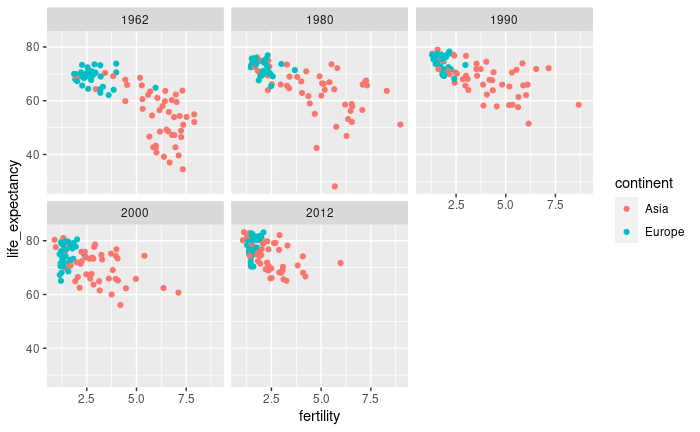

```r
years <- c(1962 , 1980 , 1990 , 2000 , 2012)
continents <- c("Europe" , "Asia")
gapminder %>%
  filter(year %in% years & continent %in% continents) %>%
  ggplot(aes(fertility, life_expectancy, col = continent)) +
  geom_point() +
  facet_wrap(~year)
```

##Time Series Plots Video This may be useful for the SITS work.  
Time will be the X=Axis and Y will be the variable of interest. geom_line function ccan be used. Best to lable the curve over using a legend.  
ABA seems to prefer the legend.

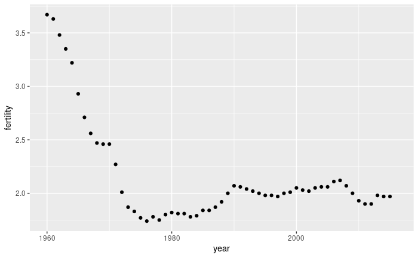

```r
#Display as point
gapminder %>%
  filter(country == "United States") %>%
  ggplot(aes(x = year, y = fertility)) +
  geom_point()
```

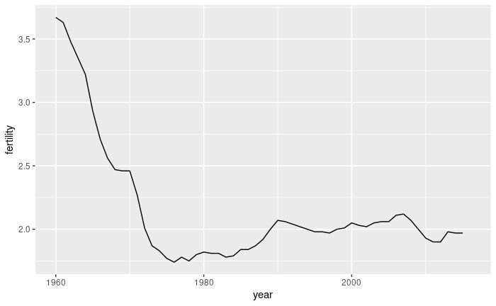

```r
# Now we will show that same data as a line graph
gapminder %>%
  filter(country =="United States") %>%
  ggplot(aes(x = year, y = fertility)) +
  geom_line()
```

We can also code multiple series of data on the same graph to compare them.

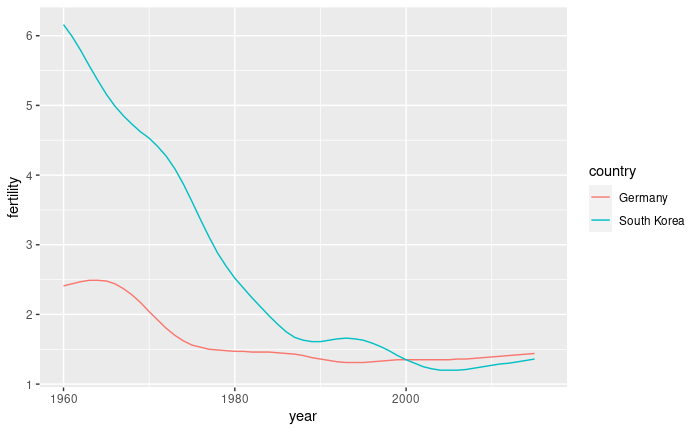

```r
countries2 <- c("Germany" , "South Korea")

gapminder %>%
  filter(country %in% countries2) %>%
  ggplot(aes(year, fertility , group = country, col = country)) +
           geom_line()
```

```r
NA
```

##Transformations Video We will look at the GDP in the Gapminder dataset It may be useful to present the data baed on the level of poverty across the population.

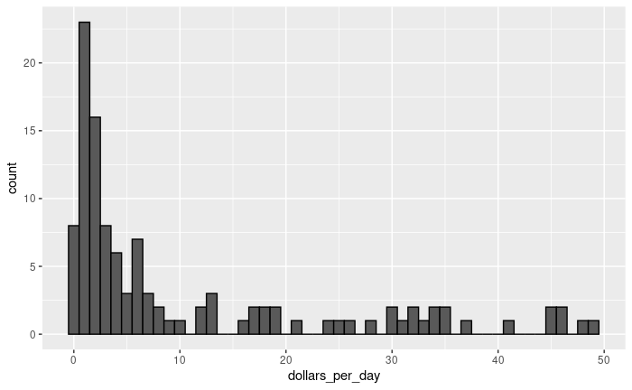

```r
library(tidyverse)
library(dplyr)
library(dslabs)
data("gapminder")
# Create the dollars per day variable
gapminder <- gapminder%>%
  mutate(dollars_per_day = gdp/population/365)
# Show the histogram for dollars per day
past_year <- 1970
gapminder %>%
  filter(year == past_year & !is.na(gdp)) %>%
  ggplot(aes(x = dollars_per_day)) +
  geom_histogram(binwidth = 1, color = "black")
```

This histogram shows tht most of the countries live under $10 per day.

log transformations - convert a multiplicative increases to additive increases.  
(Not sure what that means) When the value doubles, the log increases by 1.

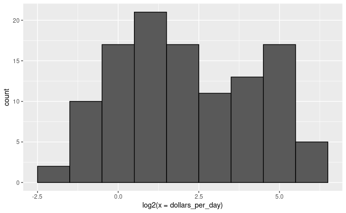

```r
gapminder %>%
  filter(year == past_year & !is.na(gdp)) %>% # this will filter the data by year and eliminate blanks
  ggplot(aes(log2(x = dollars_per_day))) +
  geom_histogram(binwidth = 1, color = "black")
```

```r
NA
```

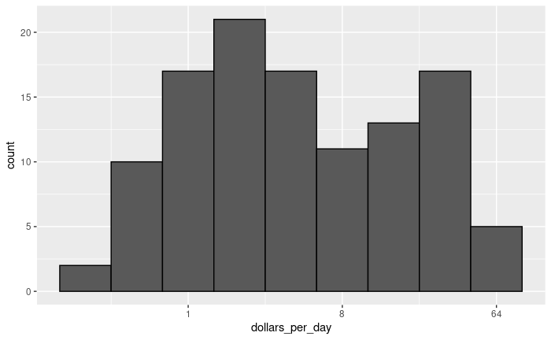

```r
gapminder %>%
  filter(year== past_year & !is.na(gdp)) %>%
  ggplot(aes(x = dollars_per_day)) +
  geom_histogram(binwidth = 1 , color = "black") +
  scale_x_continuous(trans = "log2")
```

This is the same information and the same graph, just created slightly differently by scaling the axis instead of the data. ##Data Transformations Textbook 9.5 Lets look at the population information. This is large enough that logbase10 may be the better option.

```r
filter(gapminder, year == past_year) %>%
  summarize(min = min(population), max = max(population))
```

| min | max |
| --- | --- |
| 46075 | 808510713 |

```r
NA
```

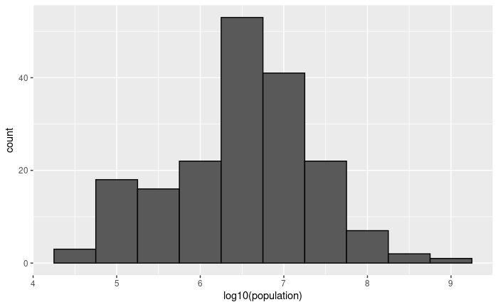

```r
gapminder %>%
  filter(year == past_year) %>%
  ggplot(aes(log10(population))) +
  geom_histogram(binwidth = 0.5, color = "black")
```

##Textbook 9.6 Visualizing multimodal distributions Typical distributions of data will follow a single curve and have a single mode.  
Often data will have multiole bumps in the data depending on the distribution. ##4.2 Stratify and Boxplot Video The histogram shows two bumps in the income, but does not show the regions or other information. Presenting multiple boxplots together can compare the data. ’ How many regions are in the gapminder data?

```r
length(levels(gapminder$region))
```

```
[1] 22
```

There are 22 regions. First lets create a boxplot to show the distributions.

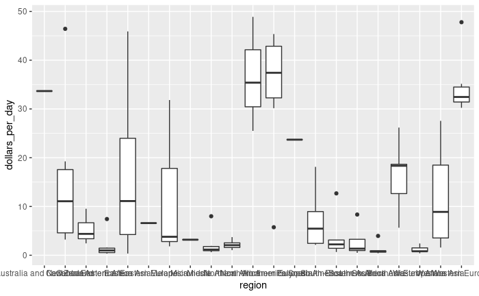

```r
past_year <- 1970
# To make things easy we will create an object for the boxplot
p <- gapminder %>%
  filter(year == past_year & !is.na(gdp)) %>%
  ggplot(aes(region, dollars_per_day))
# now we use p and change it
p +
  geom_boxplot()
```

This is difficult to read so lets alter the axis lables

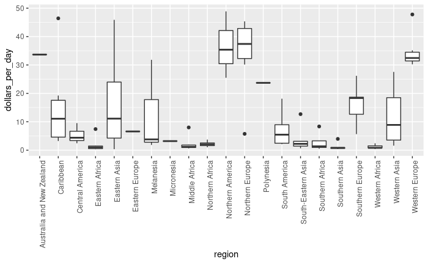

```r
p +
  geom_boxplot() +
  theme(axis.text.x = element_text(angle = 90, hjust = 1))
```

That is easier to read Now lets use reorder to organize the data a little better

```r
fac <- factor(c("Asia" , "Asia" , "West" , "West" , "West"))
levels(fac)
```

```
[1] "Asia" "West"
```

```r
value <- c(10 , 11 , 12 , 6 , 4)
fac <- reorder(fac, value, FUN = mean)
levels(fac)
```

```
[1] "West" "Asia"
```

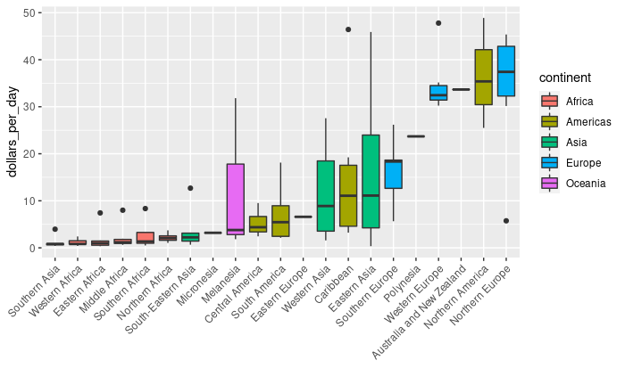

```r
p <- gapminder %>%
  filter(year == past_year & !is.na(gdp)) %>%
  mutate(region = reorder(region , dollars_per_day , FUN = median)) %>%
  ggplot(aes(region , dollars_per_day , fill = continent)) +
  geom_boxplot() +
  theme(axis.text.x = element_text(angle = 45 , hjust = 1)) +
  xlab("")
p
```

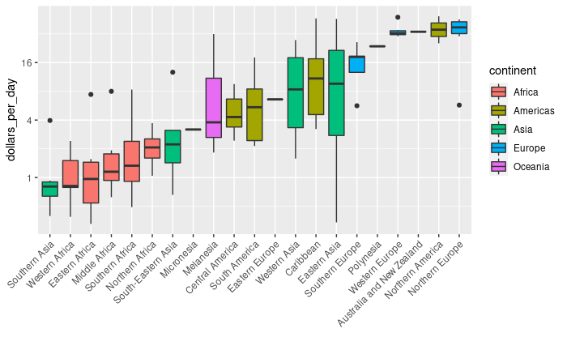

```r
#We can also present these as log scale
p +
  scale_y_continuous(trans = "log2")
```

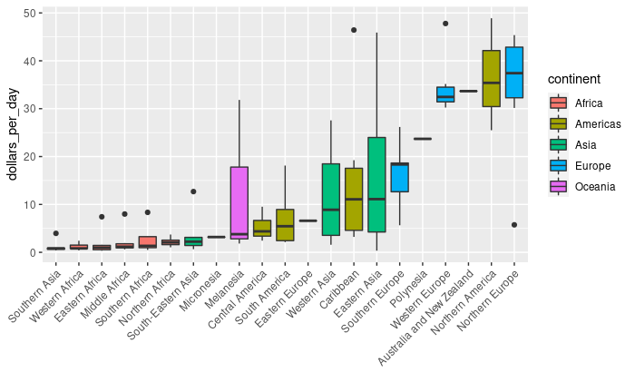

```r
p
```

##Video Ecological Fallacy We must ensure that the data we present is accurately displaying the information or we can make poor decisions.  
Ecological Fallacy - When we assume that the average applies equally to everyone in the group.

Logistic Transformation calculates the odds of a particular outcome using standard statistics.